# Risk Factor Analysis

## Outcome Variable

**Outcome Variable:** wast_rec90d

## Predictor Variables

**Intervention Variable:** predfeed3

**Adjustment Set:**

- arm
- sex
- month
- brthmon
- W_mage
- meducyrs
- feducyrs
- hhwealth_quart
- hfoodsec
- W_mhtcm
- W_mwtkg
- W_mbmi
- vagbrth
- W_gagebrth
- W_birthwt
- W_birthlen
- W_nrooms
- W_nchldlt5
- W_parity
- impfloor
- impsan
- safeh20
- delta_W_mage
- delta_meducyrs
- delta_feducyrs
- delta_hhwealth_quart
- delta_hfoodsec
- delta_W_mhtcm
- delta_W_mwtkg
- delta_W_mbmi
- delta_vagbrth
- delta_W_gagebrth
- delta_W_birthwt
- delta_W_birthlen
- delta_W_nrooms
- delta_W_nchldlt5
- delta_W_parity
- delta_impfloor
- delta_impsan
- delta_safeh20

## Stratifying Variables

The analysis was stratified on these variable(s):

- agecat
- studyid
- country

## Data Summary

| agecat | studyid | country | predfeed3 | wast_rec90d | n_cell | n |
| --- | --- | --- | --- | --- | --- | --- |
| 0-24 months | ki0047075b-MAL-ED | BANGLADESH | 1 | 0 | 33 | 117 |
| 0-24 months | ki0047075b-MAL-ED | BANGLADESH | 1 | 1 | 68 | 117 |
| 0-24 months | ki0047075b-MAL-ED | BANGLADESH | 0 | 0 | 8 | 117 |
| 0-24 months | ki0047075b-MAL-ED | BANGLADESH | 0 | 1 | 8 | 117 |
| 0-24 months | ki0047075b-MAL-ED | BRAZIL | 1 | 0 | 5 | 22 |
| 0-24 months | ki0047075b-MAL-ED | BRAZIL | 1 | 1 | 9 | 22 |
| 0-24 months | ki0047075b-MAL-ED | BRAZIL | 0 | 0 | 1 | 22 |
| 0-24 months | ki0047075b-MAL-ED | BRAZIL | 0 | 1 | 7 | 22 |
| 0-24 months | ki0047075b-MAL-ED | INDIA | 1 | 0 | 43 | 162 |
| 0-24 months | ki0047075b-MAL-ED | INDIA | 1 | 1 | 67 | 162 |
| 0-24 months | ki0047075b-MAL-ED | INDIA | 0 | 0 | 19 | 162 |
| 0-24 months | ki0047075b-MAL-ED | INDIA | 0 | 1 | 33 | 162 |
| 0-24 months | ki0047075b-MAL-ED | NEPAL | 1 | 0 | 11 | 96 |
| 0-24 months | ki0047075b-MAL-ED | NEPAL | 1 | 1 | 35 | 96 |
| 0-24 months | ki0047075b-MAL-ED | NEPAL | 0 | 0 | 9 | 96 |
| 0-24 months | ki0047075b-MAL-ED | NEPAL | 0 | 1 | 41 | 96 |
| 0-24 months | ki0047075b-MAL-ED | PERU | 1 | 0 | 3 | 33 |
| 0-24 months | ki0047075b-MAL-ED | PERU | 1 | 1 | 12 | 33 |
| 0-24 months | ki0047075b-MAL-ED | PERU | 0 | 0 | 3 | 33 |
| 0-24 months | ki0047075b-MAL-ED | PERU | 0 | 1 | 15 | 33 |
| 0-24 months | ki0047075b-MAL-ED | SOUTH AFRICA | 1 | 0 | 4 | 77 |
| 0-24 months | ki0047075b-MAL-ED | SOUTH AFRICA | 1 | 1 | 12 | 77 |
| 0-24 months | ki0047075b-MAL-ED | SOUTH AFRICA | 0 | 0 | 8 | 77 |
| 0-24 months | ki0047075b-MAL-ED | SOUTH AFRICA | 0 | 1 | 53 | 77 |
| 0-24 months | ki0047075b-MAL-ED | TANZANIA, UNITED REPUBLIC OF | 1 | 0 | 2 | 44 |
| 0-24 months | ki0047075b-MAL-ED | TANZANIA, UNITED REPUBLIC OF | 1 | 1 | 8 | 44 |
| 0-24 months | ki0047075b-MAL-ED | TANZANIA, UNITED REPUBLIC OF | 0 | 0 | 6 | 44 |
| 0-24 months | ki0047075b-MAL-ED | TANZANIA, UNITED REPUBLIC OF | 0 | 1 | 28 | 44 |
| 0-24 months | ki1000109-EE | PAKISTAN | 1 | 0 | 14 | 30 |
| 0-24 months | ki1000109-EE | PAKISTAN | 1 | 1 | 16 | 30 |

[output cut: 102 more lines]

The following strata were considered:

- agecat: 0-24 months, studyid: ki0047075b-MAL-ED, country: BANGLADESH
- agecat: 0-24 months, studyid: ki0047075b-MAL-ED, country: BRAZIL
- agecat: 0-24 months, studyid: ki0047075b-MAL-ED, country: INDIA
- agecat: 0-24 months, studyid: ki0047075b-MAL-ED, country: NEPAL
- agecat: 0-24 months, studyid: ki0047075b-MAL-ED, country: PERU
- agecat: 0-24 months, studyid: ki0047075b-MAL-ED, country: SOUTH AFRICA
- agecat: 0-24 months, studyid: ki0047075b-MAL-ED, country: TANZANIA, UNITED REPUBLIC OF
- agecat: 0-24 months, studyid: ki1000109-EE, country: PAKISTAN
- agecat: 0-24 months, studyid: ki1113344-GMS-Nepal, country: NEPAL
- agecat: 0-24 months, studyid: kiGH5241-JiVitA-3, country: BANGLADESH
- agecat: 0-24 months, studyid: kiGH5241-JiVitA-4, country: BANGLADESH
- agecat: 0-6 months, studyid: ki0047075b-MAL-ED, country: BANGLADESH
- agecat: 0-6 months, studyid: ki0047075b-MAL-ED, country: BRAZIL
- agecat: 0-6 months, studyid: ki0047075b-MAL-ED, country: INDIA
- agecat: 0-6 months, studyid: ki0047075b-MAL-ED, country: NEPAL
- agecat: 0-6 months, studyid: ki0047075b-MAL-ED, country: PERU
- agecat: 0-6 months, studyid: ki0047075b-MAL-ED, country: SOUTH AFRICA
- agecat: 0-6 months, studyid: ki0047075b-MAL-ED, country: TANZANIA, UNITED REPUBLIC OF
- agecat: 0-6 months, studyid: ki1000109-EE, country: PAKISTAN
- agecat: 0-6 months, studyid: ki1113344-GMS-Nepal, country: NEPAL
- agecat: 0-6 months, studyid: kiGH5241-JiVitA-3, country: BANGLADESH
- agecat: 0-6 months, studyid: kiGH5241-JiVitA-4, country: BANGLADESH
- agecat: 6-24 months, studyid: ki0047075b-MAL-ED, country: BANGLADESH
- agecat: 6-24 months, studyid: ki0047075b-MAL-ED, country: BRAZIL
- agecat: 6-24 months, studyid: ki0047075b-MAL-ED, country: INDIA
- agecat: 6-24 months, studyid: ki0047075b-MAL-ED, country: NEPAL
- agecat: 6-24 months, studyid: ki0047075b-MAL-ED, country: PERU
- agecat: 6-24 months, studyid: ki0047075b-MAL-ED, country: SOUTH AFRICA
- agecat: 6-24 months, studyid: ki0047075b-MAL-ED, country: TANZANIA, UNITED REPUBLIC OF
- agecat: 6-24 months, studyid: ki1000109-EE, country: PAKISTAN
- agecat: 6-24 months, studyid: ki1113344-GMS-Nepal, country: NEPAL
- agecat: 6-24 months, studyid: kiGH5241-JiVitA-3, country: BANGLADESH
- agecat: 6-24 months, studyid: kiGH5241-JiVitA-4, country: BANGLADESH

### Dropped Strata

Some strata were dropped due to rare outcomes:

- agecat: 0-24 months, studyid: ki0047075b-MAL-ED, country: BRAZIL
- agecat: 0-24 months, studyid: ki0047075b-MAL-ED, country: PERU
- agecat: 0-24 months, studyid: ki0047075b-MAL-ED, country: SOUTH AFRICA
- agecat: 0-24 months, studyid: ki0047075b-MAL-ED, country: TANZANIA, UNITED REPUBLIC OF
- agecat: 0-24 months, studyid: ki1000109-EE, country: PAKISTAN
- agecat: 0-24 months, studyid: kiGH5241-JiVitA-4, country: BANGLADESH
- agecat: 0-6 months, studyid: ki0047075b-MAL-ED, country: BANGLADESH
- agecat: 0-6 months, studyid: ki0047075b-MAL-ED, country: BRAZIL
- agecat: 0-6 months, studyid: ki0047075b-MAL-ED, country: NEPAL
- agecat: 0-6 months, studyid: ki0047075b-MAL-ED, country: PERU
- agecat: 0-6 months, studyid: ki0047075b-MAL-ED, country: SOUTH AFRICA
- agecat: 0-6 months, studyid: ki0047075b-MAL-ED, country: TANZANIA, UNITED REPUBLIC OF
- agecat: 0-6 months, studyid: ki1000109-EE, country: PAKISTAN
- agecat: 0-6 months, studyid: kiGH5241-JiVitA-4, country: BANGLADESH
- agecat: 6-24 months, studyid: ki0047075b-MAL-ED, country: BANGLADESH
- agecat: 6-24 months, studyid: ki0047075b-MAL-ED, country: BRAZIL
- agecat: 6-24 months, studyid: ki0047075b-MAL-ED, country: NEPAL
- agecat: 6-24 months, studyid: ki0047075b-MAL-ED, country: PERU
- agecat: 6-24 months, studyid: ki0047075b-MAL-ED, country: SOUTH AFRICA
- agecat: 6-24 months, studyid: ki0047075b-MAL-ED, country: TANZANIA, UNITED REPUBLIC OF
- agecat: 6-24 months, studyid: ki1000109-EE, country: PAKISTAN
- agecat: 6-24 months, studyid: kiGH5241-JiVitA-3, country: BANGLADESH
- agecat: 6-24 months, studyid: kiGH5241-JiVitA-4, country: BANGLADESH

## Methods Detail

We’re interested in the causal parameters $E[Y_a]$ for all values of $a \in \mathcal{A}$. These parameters represent the mean outcome if, possibly contrary to fact, we intervened to set all units to have $A=a$. Under the randomization and positivity assumptions, these are identified by the statistical parameters $\psi_a=E_W[E_{Y|A,W}(Y|A=a,W)]$. In addition, we’re interested in the mean of $Y$, $E[Y]$ under no intervention (the observed mean). We will estimate these parameters by using SuperLearner to fit the relevant likelihood factors – $E_{Y|A,W}(Y|A=a,W)$ and $p(A=a|W)$, and then updating our likelihood fit using a joint TMLE.

For unadjusted analyses ($W=\{\}$), initial likelihoods were estimated using Lrnr_glm to estimate the simple $E(Y|A)$ and Lrnr_mean to estimate $p(A)$. For adjusted analyses, a small library containing Lrnr_glmnet, Lrnr_xgboost, and Lrnr_mean was used.

Having estimated these parameters, we will then use the delta method to estimate relative risks and attributable risks relative to a prespecified baseline level of $A$.

# Results Detail

## Results Plots

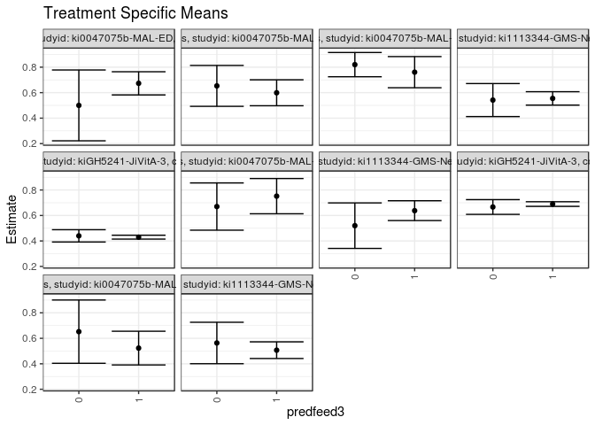

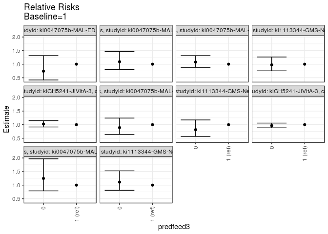

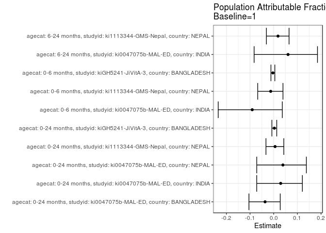

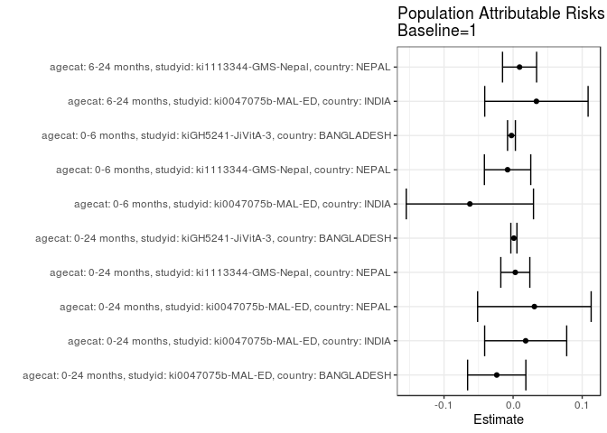

## Results Table

### Parameter: TSM

| agecat | studyid | country | intervention_level | baseline_level | estimate | ci_lower | ci_upper |
| --- | --- | --- | --- | --- | --- | --- | --- |
| 0-24 months | ki0047075b-MAL-ED | BANGLADESH | 1 | NA | 0.6732673 | 0.5822997 | 0.7642350 |
| 0-24 months | ki0047075b-MAL-ED | BANGLADESH | 0 | NA | 0.5000000 | 0.2219425 | 0.7780575 |
| 0-24 months | ki0047075b-MAL-ED | INDIA | 1 | NA | 0.5990930 | 0.4973205 | 0.7008655 |
| 0-24 months | ki0047075b-MAL-ED | INDIA | 0 | NA | 0.6530801 | 0.4926198 | 0.8135404 |
| 0-24 months | ki0047075b-MAL-ED | NEPAL | 1 | NA | 0.7608696 | 0.6384483 | 0.8832909 |
| 0-24 months | ki0047075b-MAL-ED | NEPAL | 0 | NA | 0.8200000 | 0.7247720 | 0.9152280 |
| 0-24 months | ki1113344-GMS-Nepal | NEPAL | 1 | NA | 0.5548454 | 0.5021024 | 0.6075885 |
| 0-24 months | ki1113344-GMS-Nepal | NEPAL | 0 | NA | 0.5417535 | 0.4121552 | 0.6713518 |
| 0-24 months | kiGH5241-JiVitA-3 | BANGLADESH | 1 | NA | 0.4297448 | 0.4144880 | 0.4450015 |
| 0-24 months | kiGH5241-JiVitA-3 | BANGLADESH | 0 | NA | 0.4400851 | 0.3918669 | 0.4883034 |
| 0-6 months | ki0047075b-MAL-ED | INDIA | 1 | NA | 0.7517533 | 0.6134566 | 0.8900501 |
| 0-6 months | ki0047075b-MAL-ED | INDIA | 0 | NA | 0.6700024 | 0.4845603 | 0.8554446 |
| 0-6 months | ki1113344-GMS-Nepal | NEPAL | 1 | NA | 0.6378355 | 0.5600780 | 0.7155930 |
| 0-6 months | ki1113344-GMS-Nepal | NEPAL | 0 | NA | 0.5200511 | 0.3415643 | 0.6985380 |
| 0-6 months | kiGH5241-JiVitA-3 | BANGLADESH | 1 | NA | 0.6898621 | 0.6716348 | 0.7080893 |
| 0-6 months | kiGH5241-JiVitA-3 | BANGLADESH | 0 | NA | 0.6665561 | 0.6087791 | 0.7243331 |
| 6-24 months | ki0047075b-MAL-ED | INDIA | 1 | NA | 0.5230769 | 0.3907677 | 0.6553862 |
| 6-24 months | ki0047075b-MAL-ED | INDIA | 0 | NA | 0.6521739 | 0.4038225 | 0.9005253 |
| 6-24 months | ki1113344-GMS-Nepal | NEPAL | 1 | NA | 0.5067762 | 0.4412576 | 0.5722948 |
| 6-24 months | ki1113344-GMS-Nepal | NEPAL | 0 | NA | 0.5633333 | 0.4006247 | 0.7260419 |

### Parameter: E(Y)

| agecat | studyid | country | intervention_level | baseline_level | estimate | ci_lower | ci_upper |
| --- | --- | --- | --- | --- | --- | --- | --- |
| 0-24 months | ki0047075b-MAL-ED | BANGLADESH | NA | NA | 0.6495726 | 0.5607849 | 0.7383604 |
| 0-24 months | ki0047075b-MAL-ED | INDIA | NA | NA | 0.6172840 | 0.5340594 | 0.7005085 |
| 0-24 months | ki0047075b-MAL-ED | NEPAL | NA | NA | 0.7916667 | 0.7146386 | 0.8686947 |
| 0-24 months | ki1113344-GMS-Nepal | NEPAL | NA | NA | 0.5580448 | 0.5093588 | 0.6067308 |
| 0-24 months | kiGH5241-JiVitA-3 | BANGLADESH | NA | NA | 0.4308756 | 0.4161410 | 0.4456101 |
| 0-6 months | ki0047075b-MAL-ED | INDIA | NA | NA | 0.6891892 | 0.5810852 | 0.7972932 |
| 0-6 months | ki1113344-GMS-Nepal | NEPAL | NA | NA | 0.6298343 | 0.5587812 | 0.7008873 |
| 0-6 months | kiGH5241-JiVitA-3 | BANGLADESH | NA | NA | 0.6875000 | 0.6700777 | 0.7049223 |
| 6-24 months | ki0047075b-MAL-ED | INDIA | NA | NA | 0.5568182 | 0.4384773 | 0.6751591 |
| 6-24 months | ki1113344-GMS-Nepal | NEPAL | NA | NA | 0.5161290 | 0.4555456 | 0.5767125 |

### Parameter: RR

| agecat | studyid | country | intervention_level | baseline_level | estimate | ci_lower | ci_upper |
| --- | --- | --- | --- | --- | --- | --- | --- |
| 0-24 months | ki0047075b-MAL-ED | BANGLADESH | 1 | 1 | 1.0000000 | 1.0000000 | 1.000000 |
| 0-24 months | ki0047075b-MAL-ED | BANGLADESH | 0 | 1 | 0.7426471 | 0.4190238 | 1.316213 |
| 0-24 months | ki0047075b-MAL-ED | INDIA | 1 | 1 | 1.0000000 | 1.0000000 | 1.000000 |
| 0-24 months | ki0047075b-MAL-ED | INDIA | 0 | 1 | 1.0901147 | 0.8081476 | 1.470462 |
| 0-24 months | ki0047075b-MAL-ED | NEPAL | 1 | 1 | 1.0000000 | 1.0000000 | 1.000000 |
| 0-24 months | ki0047075b-MAL-ED | NEPAL | 0 | 1 | 1.0777143 | 0.8831354 | 1.315164 |
| 0-24 months | ki1113344-GMS-Nepal | NEPAL | 1 | 1 | 1.0000000 | 1.0000000 | 1.000000 |
| 0-24 months | ki1113344-GMS-Nepal | NEPAL | 0 | 1 | 0.9764043 | 0.7545416 | 1.263503 |
| 0-24 months | kiGH5241-JiVitA-3 | BANGLADESH | 1 | 1 | 1.0000000 | 1.0000000 | 1.000000 |
| 0-24 months | kiGH5241-JiVitA-3 | BANGLADESH | 0 | 1 | 1.0240617 | 0.9142137 | 1.147109 |
| 0-6 months | ki0047075b-MAL-ED | INDIA | 1 | 1 | 1.0000000 | 1.0000000 | 1.000000 |
| 0-6 months | ki0047075b-MAL-ED | INDIA | 0 | 1 | 0.8912530 | 0.6388115 | 1.243453 |
| 0-6 months | ki1113344-GMS-Nepal | NEPAL | 1 | 1 | 1.0000000 | 1.0000000 | 1.000000 |
| 0-6 months | ki1113344-GMS-Nepal | NEPAL | 0 | 1 | 0.8153374 | 0.5659603 | 1.174597 |
| 0-6 months | kiGH5241-JiVitA-3 | BANGLADESH | 1 | 1 | 1.0000000 | 1.0000000 | 1.000000 |
| 0-6 months | kiGH5241-JiVitA-3 | BANGLADESH | 0 | 1 | 0.9662164 | 0.8827188 | 1.057612 |
| 6-24 months | ki0047075b-MAL-ED | INDIA | 1 | 1 | 1.0000000 | 1.0000000 | 1.000000 |
| 6-24 months | ki0047075b-MAL-ED | INDIA | 0 | 1 | 1.2468031 | 0.7893061 | 1.969474 |
| 6-24 months | ki1113344-GMS-Nepal | NEPAL | 1 | 1 | 1.0000000 | 1.0000000 | 1.000000 |
| 6-24 months | ki1113344-GMS-Nepal | NEPAL | 0 | 1 | 1.1116017 | 0.8097686 | 1.525940 |

### Parameter: PAR

| agecat | studyid | country | intervention_level | baseline_level | estimate | ci_lower | ci_upper |
| --- | --- | --- | --- | --- | --- | --- | --- |
| 0-24 months | ki0047075b-MAL-ED | BANGLADESH | 1 | NA | -0.0236947 | -0.0658584 | 0.0184690 |
| 0-24 months | ki0047075b-MAL-ED | INDIA | 1 | NA | 0.0181910 | -0.0411950 | 0.0775769 |
| 0-24 months | ki0047075b-MAL-ED | NEPAL | 1 | NA | 0.0307971 | -0.0513830 | 0.1129772 |
| 0-24 months | ki1113344-GMS-Nepal | NEPAL | 1 | NA | 0.0031994 | -0.0178035 | 0.0242023 |
| 0-24 months | kiGH5241-JiVitA-3 | BANGLADESH | 1 | NA | 0.0011308 | -0.0032889 | 0.0055505 |
| 0-6 months | ki0047075b-MAL-ED | INDIA | 1 | NA | -0.0625642 | -0.1546467 | 0.0295184 |
| 0-6 months | ki1113344-GMS-Nepal | NEPAL | 1 | NA | -0.0080012 | -0.0415517 | 0.0255492 |
| 0-6 months | kiGH5241-JiVitA-3 | BANGLADESH | 1 | NA | -0.0023621 | -0.0080402 | 0.0033160 |
| 6-24 months | ki0047075b-MAL-ED | INDIA | 1 | NA | 0.0337413 | -0.0410835 | 0.1085660 |
| 6-24 months | ki1113344-GMS-Nepal | NEPAL | 1 | NA | 0.0093528 | -0.0153034 | 0.0340090 |

### Parameter: PAF

| agecat | studyid | country | intervention_level | baseline_level | estimate | ci_lower | ci_upper |
| --- | --- | --- | --- | --- | --- | --- | --- |
| 0-24 months | ki0047075b-MAL-ED | BANGLADESH | 1 | NA | -0.0364773 | -0.1046400 | 0.0274793 |
| 0-24 months | ki0047075b-MAL-ED | INDIA | 1 | NA | 0.0294693 | -0.0717138 | 0.1210996 |
| 0-24 months | ki0047075b-MAL-ED | NEPAL | 1 | NA | 0.0389016 | -0.0715585 | 0.1379751 |
| 0-24 months | ki1113344-GMS-Nepal | NEPAL | 1 | NA | 0.0057332 | -0.0326208 | 0.0426626 |
| 0-24 months | kiGH5241-JiVitA-3 | BANGLADESH | 1 | NA | 0.0026245 | -0.0076837 | 0.0128272 |
| 0-6 months | ki0047075b-MAL-ED | INDIA | 1 | NA | -0.0907794 | -0.2346067 | 0.0362926 |
| 0-6 months | ki1113344-GMS-Nepal | NEPAL | 1 | NA | -0.0127037 | -0.0674591 | 0.0392430 |
| 0-6 months | kiGH5241-JiVitA-3 | BANGLADESH | 1 | NA | -0.0034357 | -0.0117309 | 0.0047914 |
| 6-24 months | ki0047075b-MAL-ED | INDIA | 1 | NA | 0.0605965 | -0.0828181 | 0.1850165 |
| 6-24 months | ki1113344-GMS-Nepal | NEPAL | 1 | NA | 0.0181211 | -0.0308919 | 0.0648039 |